# A Fast and Easy Way to Predict Words

Chen Lianghe  
15 February 2020

This presentation aims to showcase a Web-Based Shiny Application that is convenient and efficient in predicting words.

### Background & Algorithm

Natural Language Processing (NLP):

- The study of interactions between computers and human (natural) languages.
- Utilizes computer programming to process and analyze large amounts of natural language data.

N-Gram:

- A contiguous sequence of n items from a given sample of text or speech.
- Built our n-grams from a corpus named HC Corpora, which contains text from news, blogs and twitter.
- Built a text mining predictive model to determine the most likely next word from a user-specified text input.

Our Predictive Model:

- Based on the “Stupid Backoff” method described by [Brants et. al, 2007](https://www.aclweb.org/anthology/D07-1090.pdf).
- First, it checks for the highest order n-gram, a quadgram (n=4).
- If a match is not found, it proceeds to check for a trigram (n=3).
- Subsequently, it checks for a bigram (n=2) if there are still no matches.

### Our Web-Based Shiny Application

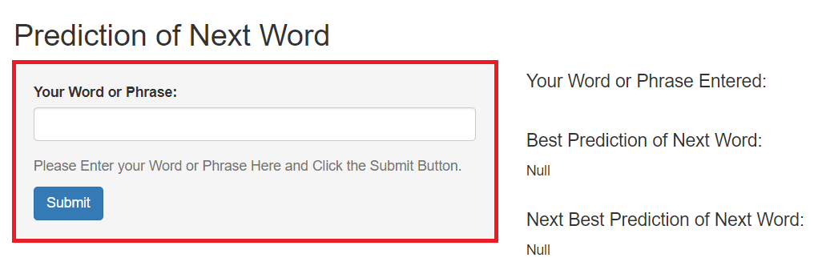

Function of the App:

- To predict the most likely next word from a user-specified text input.
- Our App is available at [shinyapps.io](https://chenlianghe.shinyapps.io/Word-Prediction/) by RStudio.

How to Use the App:

1. Enter your Word or Phrase into the Textbox provided.
2. Click the Submit Button.
3. Obtain your Predicted Result.

### An Example of a Result

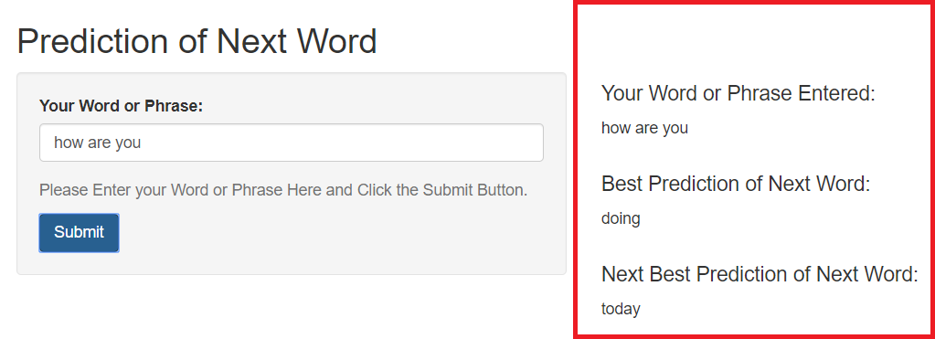

- Here, I entered the phrase: “how are you”.
- After I submitted it, the phrase was reflected under the “Your Word or Phrase Entered:” header.
- The most likely next word (“doing”) was displayed under the “Best Prediction of Next Word:” header.
- The next most likely next word (“today”) was displayed under the “Next Best Prediction of Next Word:” header.
- Essentially, this means that the 2 most likely phrases from my text input are:
  1. how are you doing
  2. how are you today

### Conclusion

Strengths of Our App:

1. Fast and returns the 2 most likely predictions within a second.
2. User-friendly app interface with clear instructions.
3. Accurate predictions that are logical and useful.

Areas of Improvement:

1. Machine Learning based on User Input:
   - N-grams can be updated by user input to provide predictions that are more accurate and specific for the user.
2. Using Higher Order N-Grams:
   - With more data, our algorithm can extend to higher order n-grams for better predictions.

Resources:

1. Our Shiny App is available at [shinyapps.io](https://chenlianghe.shinyapps.io/Word-Prediction/) by RStudio.
2. Our Source Codes are available at [GitHub](https://github.com/Lianghe-Chen/Data-Science-Capstone-Final-Project-Submission.git).

Thank You Very Much!